# Project_Model_Tuning_ReneWind_FullCode

## Problem Statement

### Business Context

Renewable energy sources play an increasingly important role in the global energy mix, as the effort to reduce the environmental impact of energy production increases.

Out of all the renewable energy alternatives, wind energy is one of the most developed technologies worldwide. The U.S Department of Energy has put together a guide to achieving operational efficiency using predictive maintenance practices.

Predictive maintenance uses sensor information and analysis methods to measure and predict degradation and future component capability. The idea behind predictive maintenance is that failure patterns are predictable and if component failure can be predicted accurately and the component is replaced before it fails, the costs of operation and maintenance will be much lower.

The sensors fitted across different machines involved in the process of energy generation collect data related to various environmental factors (temperature, humidity, wind speed, etc.) and additional features related to various parts of the wind turbine (gearbox, tower, blades, break, etc.).

## Objective

“ReneWind” is a company working on improving the machinery/processes involved in the production of wind energy using machine learning and has collected data of generator failure of wind turbines using sensors. They have shared a ciphered version of the data, as the data collected through sensors is confidential (the type of data collected varies with companies). Data has 40 predictors, 20000 observations in the training set and 5000 in the test set.

The objective is to build various classification models, tune them, and find the best one that will help identify failures so that the generators could be repaired before failing/breaking to reduce the overall maintenance cost. The nature of predictions made by the classification model will translate as follows:

- True positives (TP) are failures correctly predicted by the model. These will result in repairing costs.
- False negatives (FN) are real failures where there is no detection by the model. These will result in replacement costs.
- False positives (FP) are detections where there is no failure. These will result in inspection costs.

It is given that the cost of repairing a generator is much less than the cost of replacing it, and the cost of inspection is less than the cost of repair.

“1” in the target variables should be considered as “failure” and “0” represents “No failure”.

## Data Description

- The data provided is a transformed version of original data which was collected using sensors.
- Train.csv - To be used for training and tuning of models.
- Test.csv - To be used only for testing the performance of the final best model.
- Both the datasets consist of 40 predictor variables and 1 target variable

## Importing Libraries

```python
# Insatalling imblearn library
#!pip install imblearn --user
#!pip install xgboost --user
```

```python
# Suppressing warnings
import warnings
warnings.simplefilter('ignore')

# Data management libraries
import numpy as np
import pandas as pd

# Visualization libraries
import matplotlib.pyplot as plt
import seaborn as sns
%matplotlib inline

# Statistical libraries
import scipy.stats as stats

# Data preparation libraries
from sklearn.model_selection import train_test_split
from sklearn.impute import SimpleImputer, KNNImputer
from sklearn.preprocessing import StandardScaler, MinMaxScaler, OneHotEncoder

# Model tuning libraries
from sklearn.model_selection import GridSearchCV, RandomizedSearchCV
from sklearn.model_selection import KFold, StratifiedKFold, cross_val_score

# Up/downsampling libraries
from imblearn.under_sampling import TomekLinks, RandomUnderSampler
from imblearn.over_sampling import SMOTE, RandomOverSampler

# Classification libraries
from sklearn.linear_model import LogisticRegression
from sklearn.tree import DecisionTreeClassifier
from sklearn.ensemble import (BaggingClassifier, RandomForestClassifier,
                              AdaBoostClassifier, GradientBoostingClassifier)
from xgboost import XGBClassifier
from sklearn.metrics import (accuracy_score, recall_score, precision_score,
                             f1_score, confusion_matrix, make_scorer)

# Productionization libraries
from sklearn.pipeline import Pipeline, make_pipeline
from sklearn.compose import ColumnTransformer

# Setting the theme and fontsize of figures
sns.set_theme(style = 'darkgrid', font_scale = 1.13)
# Restricting the float value of a dataframe to 3 decimal points
pd.set_option('display.float_format', lambda x: '%.3f' % x)
# Removing the limit for the number of displayed columns in a dataframe
pd.set_option("display.max_columns", None)
```

## Loading the Dataset

Note that, in the following, training data refers to 'Train_project.csv' loaded from Google Drive into a dataframe, while what's created after splitting this dataframe into training and validation parts, and is used for training the ML models, will be called training set.

```python
# Reading training and testing data
data = pd.read_csv('Train_project.csv')
data_test = pd.read_csv('Test_project.csv')

# Ensuring that original training and testing data won't be altered
df = data.copy()
df_test = data_test.copy()
```

## Data Overview

- Observations
- Sanity checks

### Viewing the Top and Bottom of the Dataset

```python
# First 5 rows of train set
print('First five rows of the training data:')
df.head()
```

[output not shown]

|  | V1 | V2 | V3 | V4 | V5 | V6 | V7 | V8 | V9 | V10 | V11 | V12 | V13 | V14 | V15 | V16 | V17 | V18 | V19 | V20 | V21 | V22 | V23 | V24 | V25 | V26 | V27 | V28 | V29 | … |
| --- | --- | --- | --- | --- | --- | --- | --- | --- | --- | --- | --- | --- | --- | --- | --- | --- | --- | --- | --- | --- | --- | --- | --- | --- | --- | --- | --- | --- | --- | --- |
| 0 | -4.465 | -4.679 | 3.102 | 0.506 | -0.221 | -2.033 | -2.911 | 0.051 | -1.522 | 3.762 | -5.715 | 0.736 | 0.981 | 1.418 | -3.376 | -3.047 | 0.306 | 2.914 | 2.270 | 4.395 | -2.388 | 0.646 | -1.191 | 3.133 | 0.665 | -2.511 | -0.037 | 0.726 | -3.982 | … |
| 1 | 3.366 | 3.653 | 0.910 | -1.368 | 0.332 | 2.359 | 0.733 | -4.332 | 0.566 | -0.101 | 1.914 | -0.951 | -1.255 | -2.707 | 0.193 | -4.769 | -2.205 | 0.908 | 0.757 | -5.834 | -3.065 | 1.597 | -1.757 | 1.766 | -0.267 | 3.625 | 1.500 | -0.586 | 0.783 | … |
| 2 | -3.832 | -5.824 | 0.634 | -2.419 | -1.774 | 1.017 | -2.099 | -3.173 | -2.082 | 5.393 | -0.771 | 1.107 | 1.144 | 0.943 | -3.164 | -4.248 | -4.039 | 3.689 | 3.311 | 1.059 | -2.143 | 1.650 | -1.661 | 1.680 | -0.451 | -4.551 | 3.739 | 1.134 | -2.034 | … |
| 3 | 1.618 | 1.888 | 7.046 | -1.147 | 0.083 | -1.530 | 0.207 | -2.494 | 0.345 | 2.119 | -3.053 | 0.460 | 2.705 | -0.636 | -0.454 | -3.174 | -3.404 | -1.282 | 1.582 | -1.952 | -3.517 | -1.206 | -5.628 | -1.818 | 2.124 | 5.295 | 4.748 | -2.309 | -3.963 | … |
| 4 | -0.111 | 3.872 | -3.758 | -2.983 | 3.793 | 0.545 | 0.205 | 4.849 | -1.855 | -6.220 | 1.998 | 4.724 | 0.709 | -1.989 | -2.633 | 4.184 | 2.245 | 3.734 | -6.313 | -5.380 | -0.887 | 2.062 | 9.446 | 4.490 | -3.945 | 4.582 | -8.780 | -3.383 | 5.107 | … |

```python
# Last 5 rows of train set
print('Last five rows of the training data:')
df.tail()
```

[output not shown]

|  | V1 | V2 | V3 | V4 | V5 | V6 | V7 | V8 | V9 | V10 | V11 | V12 | V13 | V14 | V15 | V16 | V17 | V18 | V19 | V20 | V21 | V22 | V23 | V24 | V25 | V26 | V27 | V28 | V29 | … |
| --- | --- | --- | --- | --- | --- | --- | --- | --- | --- | --- | --- | --- | --- | --- | --- | --- | --- | --- | --- | --- | --- | --- | --- | --- | --- | --- | --- | --- | --- | --- |
| 19995 | -2.071 | -1.088 | -0.796 | -3.012 | -2.288 | 2.807 | 0.481 | 0.105 | -0.587 | -2.899 | 8.868 | 1.717 | 1.358 | -1.777 | 0.710 | 4.945 | -3.100 | -1.199 | -1.085 | -0.365 | 3.131 | -3.948 | -3.578 | -8.139 | -1.937 | -1.328 | -0.403 | -1.735 | 9.996 | … |
| 19996 | 2.890 | 2.483 | 5.644 | 0.937 | -1.381 | 0.412 | -1.593 | -5.762 | 2.150 | 0.272 | -2.095 | -1.526 | 0.072 | -3.540 | -2.762 | -10.632 | -0.495 | 1.720 | 3.872 | -1.210 | -8.222 | 2.121 | -5.492 | 1.452 | 1.450 | 3.685 | 1.077 | -0.384 | -0.839 | … |
| 19997 | -3.897 | -3.942 | -0.351 | -2.417 | 1.108 | -1.528 | -3.520 | 2.055 | -0.234 | -0.358 | -3.782 | 2.180 | 6.112 | 1.985 | -8.330 | -1.639 | -0.915 | 5.672 | -3.924 | 2.133 | -4.502 | 2.777 | 5.728 | 1.620 | -1.700 | -0.042 | -2.923 | -2.760 | -2.254 | … |
| 19998 | -3.187 | -10.052 | 5.696 | -4.370 | -5.355 | -1.873 | -3.947 | 0.679 | -2.389 | 5.457 | 1.583 | 3.571 | 9.227 | 2.554 | -7.039 | -0.994 | -9.665 | 1.155 | 3.877 | 3.524 | -7.015 | -0.132 | -3.446 | -4.801 | -0.876 | -3.812 | 5.422 | -3.732 | 0.609 | … |
| 19999 | -2.687 | 1.961 | 6.137 | 2.600 | 2.657 | -4.291 | -2.344 | 0.974 | -1.027 | 0.497 | -9.589 | 3.177 | 1.055 | -1.416 | -4.669 | -5.405 | 3.720 | 2.893 | 2.329 | 1.458 | -6.429 | 1.818 | 0.806 | 7.786 | 0.331 | 5.257 | -4.867 | -0.819 | -5.667 | … |

```python
# First 5 rows of test set
print('First five rows of the testing data:')
df_test.head()
```

[output not shown]

|  | V1 | V2 | V3 | V4 | V5 | V6 | V7 | V8 | V9 | V10 | V11 | V12 | V13 | V14 | V15 | V16 | V17 | V18 | V19 | V20 | V21 | V22 | V23 | V24 | V25 | V26 | V27 | V28 | V29 | … |
| --- | --- | --- | --- | --- | --- | --- | --- | --- | --- | --- | --- | --- | --- | --- | --- | --- | --- | --- | --- | --- | --- | --- | --- | --- | --- | --- | --- | --- | --- | --- |
| 0 | -0.613 | -3.820 | 2.202 | 1.300 | -1.185 | -4.496 | -1.836 | 4.723 | 1.206 | -0.342 | -5.123 | 1.017 | 4.819 | 3.269 | -2.984 | 1.387 | 2.032 | -0.512 | -1.023 | 7.339 | -2.242 | 0.155 | 2.054 | -2.772 | 1.851 | -1.789 | -0.277 | -1.255 | -3.833 | … |
| 1 | 0.390 | -0.512 | 0.527 | -2.577 | -1.017 | 2.235 | -0.441 | -4.406 | -0.333 | 1.967 | 1.797 | 0.410 | 0.638 | -1.390 | -1.883 | -5.018 | -3.827 | 2.418 | 1.762 | -3.242 | -3.193 | 1.857 | -1.708 | 0.633 | -0.588 | 0.084 | 3.014 | -0.182 | 0.224 | … |
| 2 | -0.875 | -0.641 | 4.084 | -1.590 | 0.526 | -1.958 | -0.695 | 1.347 | -1.732 | 0.466 | -4.928 | 3.565 | -0.449 | -0.656 | -0.167 | -1.630 | 2.292 | 2.396 | 0.601 | 1.794 | -2.120 | 0.482 | -0.841 | 1.790 | 1.874 | 0.364 | -0.169 | -0.484 | -2.119 | … |
| 3 | 0.238 | 1.459 | 4.015 | 2.534 | 1.197 | -3.117 | -0.924 | 0.269 | 1.322 | 0.702 | -5.578 | -0.851 | 2.591 | 0.767 | -2.391 | -2.342 | 0.572 | -0.934 | 0.509 | 1.211 | -3.260 | 0.105 | -0.659 | 1.498 | 1.100 | 4.143 | -0.248 | -1.137 | -5.356 | … |
| 4 | 5.828 | 2.768 | -1.235 | 2.809 | -1.642 | -1.407 | 0.569 | 0.965 | 1.918 | -2.775 | -0.530 | 1.375 | -0.651 | -1.679 | -0.379 | -4.443 | 3.894 | -0.608 | 2.945 | 0.367 | -5.789 | 4.598 | 4.450 | 3.225 | 0.397 | 0.248 | -2.362 | 1.079 | -0.473 | … |

```python
# Last 5 rows of test set
print('Last five rows of the testing data:')
df_test.tail()
```

[output not shown]

[output not shown]

#### Observations:

A quick review of the first and last few records of both datasets show that they comprise the same features, and look very similar, but its further confirmation is left for the next steps.

### Shape of the Dataset

```python
print('The training data has {} records and {} features.'.format(df.shape[0], df.shape[1]))
print('The testing data has {} records and {} features.'.format(df_test.shape[0], df_test.shape[1]))
```

```
The training data has 20000 records and 41 features.
The testing data has 5000 records and 41 features.
```

#### Observations:

The size of the testing data is one quarter of that of the training data.

### Data Types

```python
print('General information on the columns of the training data:')
df.info()
```

```
General information on the columns of the training data:
<class 'pandas.core.frame.DataFrame'>
RangeIndex: 20000 entries, 0 to 19999
Data columns (total 41 columns):
 #   Column  Non-Null Count  Dtype
---  ------  --------------  -----
 0   V1      19982 non-null  float64
 1   V2      19982 non-null  float64
 2   V3      20000 non-null  float64
 3   V4      20000 non-null  float64
 4   V5      20000 non-null  float64
 5   V6      20000 non-null  float64
 6   V7      20000 non-null  float64
 7   V8      20000 non-null  float64
 8   V9      20000 non-null  float64
```

[output cut: 34 more lines]

```python
print('General information on the columns of the testing data:')
df_test.info()
```

```
General information on the columns of the testing data:
<class 'pandas.core.frame.DataFrame'>
RangeIndex: 5000 entries, 0 to 4999
Data columns (total 41 columns):
 #   Column  Non-Null Count  Dtype
---  ------  --------------  -----
 0   V1      4995 non-null   float64
 1   V2      4994 non-null   float64
 2   V3      5000 non-null   float64
 3   V4      5000 non-null   float64
 4   V5      5000 non-null   float64
 5   V6      5000 non-null   float64
 6   V7      5000 non-null   float64
 7   V8      5000 non-null   float64
 8   V9      5000 non-null   float64
```

[output cut: 34 more lines]

#### Observations:

- Both training and testing data are made up of 40 numerical, float-type variables and one target variable (integer-type) that only takes two values (classes) (0: no failure, 1: failure), indicating that the target variable is in practice categorical.
- Both datasets have a few missing values for V1 and V2 features.

### Missing Values and Duplicates

```python
# Duplicates
print('The training data has {} duplicated records.'.format(df.duplicated().sum()))
print('The testing data has {} duplicated records.'.format(df_test.duplicated().sum()))
```

```
The training data has 0 duplicated records.
The testing data has 0 duplicated records.
```

```python
# Missing values
print('Percentage of missing values for different columns of the training data:')
for col in df.columns.tolist():
    if(df[col].isnull().sum()):
      print(str(col) + ': ' + str(round(df[col].isnull().sum()/df.shape[0]*100, 3)) + '%')

# Missing values
print('\nPercentage of missing values for different columns of the testing data:')
for col in df.columns.tolist():
    if(df[col].isnull().sum()):
      print(str(col) + ': ' + str(round(df_test[col].isnull().sum()/df_test.shape[0]*100, 3)) + '%')
```

```
Percentage of missing values for different columns of the training data:
V1: 0.09%
V2: 0.09%

Percentage of missing values for different columns of the testing data:
V1: 0.1%
V2: 0.12%
```

#### Observations:

- Both datasets have similar fractions of missing values in the same columns.
- The fractions of missing values for both are really small, with the testing set having slightly larger fractions. This is a good sign, as it shows the quality of our ML-based modeling will barely be impacted by a few missing values, and the method chosen for treatting them.
- Note that the columns not listed above have no missing values.

### Statistical Summary

- Since there are too many continuous numerical variables, we limit their statistical summary only to the training data. Nonetheless, both datasets are supposed to have come from the same populations (distributions), therefore study of one should give insights into the other as well.
- We will convert the target variable into a categorical variable, with its classes being labeled as 'No Failure' and 'Failure' only for statistical summary and univariate analysis parts.

```python
# Relabeling the classes of target
df['Target'] = df['Target'].replace([0, 1], ['No Failure', 'Failure'])
df_test['Target'] = df_test['Target'].replace([0, 1], ['No Failure', 'Failure'])

# Converting target into a categorical variable
df['Target'] = df['Target'].astype('category')
df_test['Target'] = df_test['Target'].astype('category')
```

```python
# Statistical summary of numerical variables
num_summary = df.describe(include = np.number).T
num_summary = num_summary.drop(columns = 'count', axis = 1)
# Generating a new statistical feature (range)
num_summary['range'] = num_summary['max'] - num_summary['min']
num_summary.T
```

|  | V1 | V2 | V3 | V4 | V5 | V6 | V7 | V8 | V9 | V10 | V11 | V12 | V13 | V14 | V15 | V16 | V17 | V18 | V19 | V20 | V21 | V22 | V23 | V24 | V25 | V26 | V27 | V28 | V29 | … |
| --- | --- | --- | --- | --- | --- | --- | --- | --- | --- | --- | --- | --- | --- | --- | --- | --- | --- | --- | --- | --- | --- | --- | --- | --- | --- | --- | --- | --- | --- | --- |
| mean | -0.272 | 0.440 | 2.485 | -0.083 | -0.054 | -0.995 | -0.879 | -0.548 | -0.017 | -0.013 | -1.895 | 1.605 | 1.580 | -0.951 | -2.415 | -2.925 | -0.134 | 1.189 | 1.182 | 0.024 | -3.611 | 0.952 | -0.366 | 1.134 | -0.002 | 1.874 | -0.612 | -0.883 | -0.986 | … |
| std | 3.442 | 3.151 | 3.389 | 3.432 | 2.105 | 2.041 | 1.762 | 3.296 | 2.161 | 2.193 | 3.124 | 2.930 | 2.875 | 1.790 | 3.355 | 4.222 | 3.345 | 2.592 | 3.397 | 3.669 | 3.568 | 1.652 | 4.032 | 3.912 | 2.017 | 3.435 | 4.369 | 1.918 | 2.684 | … |
| min | -11.876 | -12.320 | -10.708 | -15.082 | -8.603 | -10.227 | -7.950 | -15.658 | -8.596 | -9.854 | -14.832 | -12.948 | -13.228 | -7.739 | -16.417 | -20.374 | -14.091 | -11.644 | -13.492 | -13.923 | -17.956 | -10.122 | -14.866 | -16.387 | -8.228 | -11.834 | -14.905 | -9.269 | -12.579 | … |
| 25% | -2.737 | -1.641 | 0.207 | -2.348 | -1.536 | -2.347 | -2.031 | -2.643 | -1.495 | -1.411 | -3.922 | -0.397 | -0.224 | -2.171 | -4.415 | -5.634 | -2.216 | -0.404 | -1.050 | -2.433 | -5.930 | -0.118 | -3.099 | -1.468 | -1.365 | -0.338 | -3.652 | -2.171 | -2.787 | … |
| 50% | -0.748 | 0.472 | 2.256 | -0.135 | -0.102 | -1.001 | -0.917 | -0.389 | -0.068 | 0.101 | -1.921 | 1.508 | 1.637 | -0.957 | -2.383 | -2.683 | -0.015 | 0.883 | 1.279 | 0.033 | -3.533 | 0.975 | -0.262 | 0.969 | 0.025 | 1.951 | -0.885 | -0.891 | -1.176 | … |
| 75% | 1.840 | 2.544 | 4.566 | 2.131 | 1.340 | 0.380 | 0.224 | 1.723 | 1.409 | 1.477 | 0.119 | 3.571 | 3.460 | 0.271 | -0.359 | -0.095 | 2.069 | 2.572 | 3.493 | 2.512 | -1.266 | 2.026 | 2.452 | 3.546 | 1.397 | 4.130 | 2.189 | 0.376 | 0.630 | … |
| max | 15.493 | 13.089 | 17.091 | 13.236 | 8.134 | 6.976 | 8.006 | 11.679 | 8.138 | 8.108 | 11.826 | 15.081 | 15.420 | 5.671 | 12.246 | 13.583 | 16.756 | 13.180 | 13.238 | 16.052 | 13.840 | 7.410 | 14.459 | 17.163 | 8.223 | 16.836 | 17.560 | 6.528 | 10.722 | … |
| range | 27.369 | 25.409 | 27.799 | 28.318 | 16.737 | 17.203 | 15.956 | 27.337 | 16.734 | 17.962 | 26.658 | 28.029 | 28.648 | 13.409 | 28.663 | 33.957 | 30.848 | 24.824 | 26.730 | 29.975 | 31.797 | 17.532 | 29.325 | 33.550 | 16.452 | 28.671 | 32.465 | 15.797 | 23.302 | … |

#### Observations:

- For all columns, minimum values are negative and maximum values are positive and they both relatively close magnitudes, causing the mean values to fluctuate around 0, with the smallest and leargest means to be ~ -3.6 and ~ 2.5, respectively.
- However all features span over a wide range, it is difficult to speculate whether the distribution of numerical features are skewed or not from above table and before depiction of their distribution plots. Note that, although ranges are fairly large, but minimum and maximum values of each feature are not too far from on another in magnitude.

```python
# Target variable
cat_summary = pd.concat([df.describe(include = ['object', 'category']).T,
                        df_test.describe(include = ['object', 'category']).T])
cat_summary.index = ['Train', 'Test']
cat_summary['fraction'] = cat_summary['freq']/cat_summary['count']
cat_summary
```

|  | count | unique | top | freq | fraction |
| --- | --- | --- | --- | --- | --- |
| Train | 20000 | 2 | No Failure | 18890 | 0.945 |
| Test | 5000 | 2 | No Failure | 4718 | 0.944 |

#### Observations:

For both datasets, 'No Failure' is the majority target class, with nearly the same fraction (94.5% for training and 94.4% for testing), reinforcing the applicability of the model developed on the training data to the testing data and the fact that both datasets have been drawn from the same populations (distributions).

## Exploratory Data Analysis (EDA)

```python
# Auxiliary function for annotating the bars in a countplot
def countplot_labeling(cntplt, data, perc = True, decimal = 1):
  ''' This function gets a countplot and the dataset that has generated
  the plot to produce the values corresponding to each bar (category).
  If perc = True, percentages will be shown.'''

  from math import isnan

  total = data.shape[0]  # total number of values in the dataset
  for p in cntplt.patches:
        height_val = float(p.get_height())
        if(isnan(height_val)):
          height_val = 0
        if(abs(height_val - round(height_val)) < 1e-6):
          height_val = int(height_val)
        if perc == True:
          # percentage of each category
          label = "{:.1f}%".format(100*height_val/total)
        else:
          label = "{}".format(round(height_val,decimal))  # count of each category
        x = p.get_x() + p.get_width()/2  # width of the plot
        y = p.get_height()  # height of the plot

        if(height_val == 0):
          label = '0'

        # annotate the bar
        cntplt.annotate(label, (x, y), ha = "center", va = "center", size = 12, xytext = (0, 5), textcoords = "offset points")
```

### Univariate Analysis

In this section, we will demonstrate the distributions of all 40 numerical variables in the form of histograms and boxplots, an will represent the frequency of target classes using a countplot.

**`V1 to V40`**

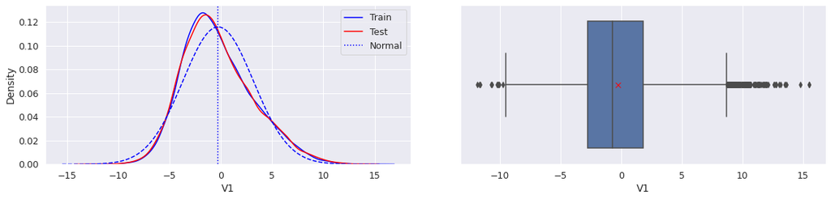

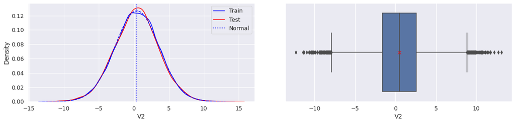

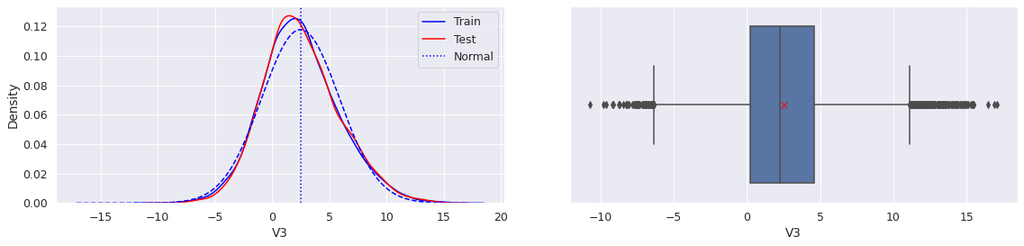

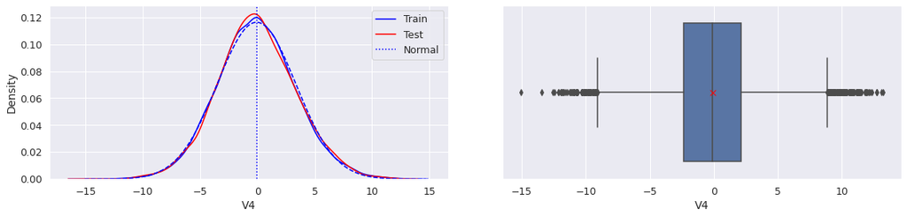

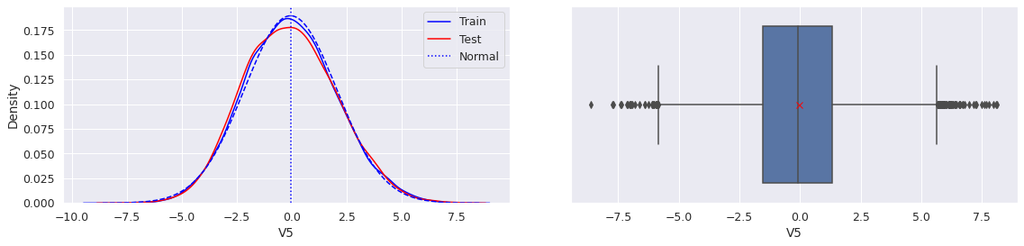

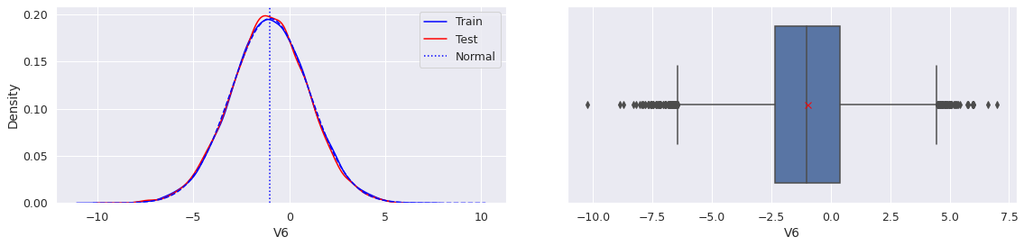

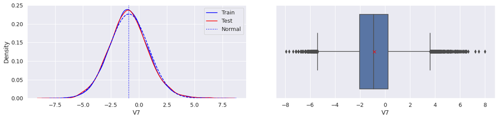

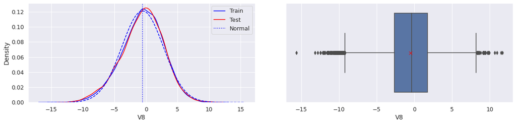

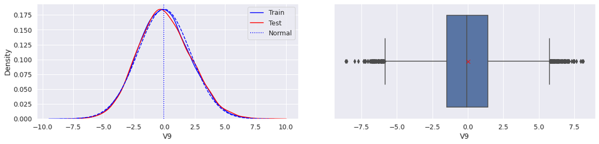

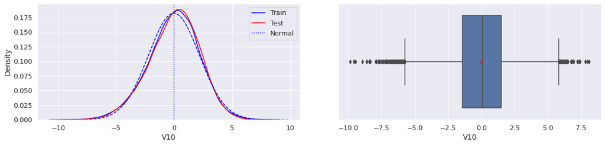

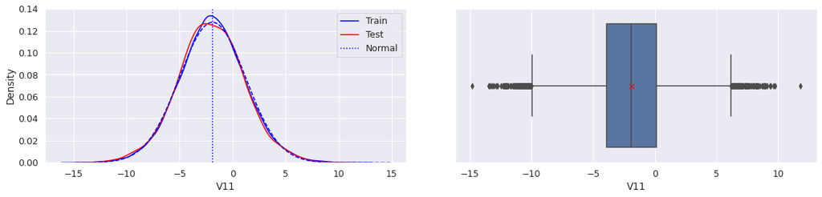

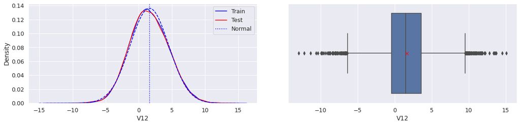

[28 more figures not shown]

```python
# Doing a loop over all continuous numerical columns to plot their distributions
for col in df.select_dtypes(include = np.number).columns.tolist():
    # Calculating the equivalent normal distribution (mu and sigma come from training)
    var_scale = max(abs(df[col].min()), df[col].max())
    norm_dist_x = np.linspace(-var_scale, var_scale, 200)
    norm_dist_y = stats.norm.pdf(norm_dist_x, loc = df[col].mean(), scale = df[col].std(ddof = 1))
    plt.figure(figsize = (16, 4));
    # KDE plots
    plt.subplot(121);
    sns.kdeplot(data = df, x = col, color = 'blue');
    sns.kdeplot(data = df_test, x = col, color = 'red');
    plt.axvline(df[col].mean(), linestyle = ':', color = 'blue');
    plt.plot(norm_dist_x, norm_dist_y, linestyle = '--', color = 'blue');
    plt.legend(['Train', 'Test', 'Normal']);
    # Boxplots
    plt.subplot(122);
    sns.boxplot(data = df, x = col, showmeans = True, meanprops =
                {'marker': 'x', 'markerfacecolor': 'red', 'markeredgecolor': 'red', 'markersize': '7'});
    plt.tight_layout(w_pad = 5);
```

#### Observations:

- The dashed blue lines show the equivalent normal distributions whose mean and standard deviation are identical to those of the plotted variable from the training data. The vertical dotted lines indicate the mean value of the plotted feature from the training data.
- For the sake of comparison, the KDE plots for both training (solid blue) and testing data (solid red) have been shown. As can be seen, for all variables, the KDE plots of the training and testing datasets look very similar, indicating that both datasets have been drawn from the same populations (distributions).
- Most variables resemble a normal distribution. For some like V6 and V38 the similarity is manifest, and for some such as V18 and V34 the match isn't strong.
- This behavior shouldn't be surprising, as most natural phenomena and engineering processes, including those emerging in wind energy production, follow normal distributions.
- For all variables, mean and median are fairly close to each other. Of course, when a distribution is closer to normal, the difference between the two is even smaller.
- There are outliers appearing on both sides of the boxplot for all features, but they all look fairly continuous and part of the actual data and given distributions. Thus, none of them raises a red flag or requires outlier treatment.

**`Target`**

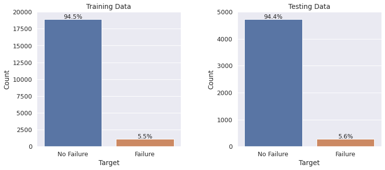

```python
plt.figure(figsize = (11, 5));
plt.subplot(121);
cntplt1 =  sns.countplot(data = df, x = 'Target', order = ['No Failure', 'Failure']);
countplot_labeling(cntplt1, df);
plt.ylabel('Count');
plt.title('Training Data');
plt.ylim(0, 20000);
plt.subplot(122);
cntplt2 =  sns.countplot(data = df_test, x = 'Target', order = ['No Failure', 'Failure']);
countplot_labeling(cntplt2, df_test);
plt.ylabel('Count');
plt.ylim(0, 5000);
plt.title('Testing Data');
plt.tight_layout(w_pad = 4);
```

#### Observations:

- The fractions of failure and no failure records are nearly identical in both datasets, again, signaling that they both have come from the same distributions, and a model developed for the training data can be readily applied to the tesing data.

### Bivariate Analysis

There are tens of variables in the dataset, whose real meaning and nature have been masked from us. Furthermore, exploring all permutations of these variables is a very cumbersome task. For these reasons, we keep bivariate analysis brief, and will only examine the correlation between the predictors and the target variable (failure).

```python
# Converting the target back into a numerical variable
df['Target'] = df['Target'].replace(['No Failure', 'Failure'], [0, 1])
df_test['Target'] = df_test['Target'].replace(['No Failure', 'Failure'], [0, 1])
df['Target'] = df['Target'].astype(int)
df_test['Target'] = df_test['Target'].astype(int)
```

```python
# Calculating the correlation coefficient between predictors and target variable
corr_with_target = df.corr().iloc[-1, :-1]
corr_with_target_test = df_test.corr().iloc[-1, :-1]

print('Predictors with strong correlation with the target (train):\n',
      corr_with_target.loc[corr_with_target.values >= 0.2].sort_values(ascending = False),
      sep = '', end = '\n' + '**'*30 + '\n')
print('Predictors with strong correlation with the target (test):\n',
      corr_with_target_test.loc[corr_with_target_test.values >= 0.2].sort_values(ascending = False), sep = '')
```

```
Predictors with strong correlation with the target (train):
V21   0.256
V15   0.249
V7    0.237
V16   0.231
V28   0.207
Name: Target, dtype: float64
Predictors with strong correlation with the target (test):
V21   0.260
V15   0.256
V7    0.224
V28   0.223
V16   0.222
Name: Target, dtype: float64
```

#### Observations:

- Above, all predictors with strong correlation with the target variables have been listed on both datasets. The threshold for strong correlation has been selected as CC $\geq$ 0.2.
- Interestingly, the same predictors have been picked for both datasets as the ones with the highest correlation with the target (with minor difference of the fourth and fifth being swapped), while correlation coefficients haven't changed much either, further corroborating that both datasets have the same underlying statistics.

## Data Preprocessing

### Data Splitting

In order to make the size of validation and test sets sets equal, we split the training data into training and validation sets with a 75:25 ratio.

```python
# Separating predictors from the target
X = df.drop(columns = 'Target', axis = 1)
y = df['Target']
X_test = df_test.drop(columns = 'Target', axis = 1)
y_test = df_test['Target']

# Splitting the training data into training and validation sets
X_train, X_valid, y_train, y_valid = train_test_split(X, y, train_size = 0.75, stratify = y, random_state = 1)

# Checking the fraction of target classes for various sets
print('The fractions of target classes for the original (training) data:\n', y.value_counts(1),
      end = '\n' + '**'*35 + '\n', sep = '')
print('The fractions of target classes for the training set:\n', y_train.value_counts(1),
      end = '\n' + '**'*35 + '\n', sep = '')
print('The fractions of target classes for the validation set:\n', y_valid.value_counts(1),
      end = '\n' + '**'*35 + '\n', sep = '')
print('The fractions of target classes for the test set:\n', y_test.value_counts(1),
      end = '\n' + '**'*35 + '\n', sep = '')
print('The size of training, validation and test sets, respectively:\n' +
      str(X_train.shape) + ', ' + str(X_valid.shape) + ', ' + str(X_test.shape))
```

```
The fractions of target classes for the original (training) data:
0   0.945
1   0.056
Name: Target, dtype: float64
The fractions of target classes for the training set:
0   0.945
1   0.055
Name: Target, dtype: float64
The fractions of target classes for the validation set:
0   0.944
1   0.056
Name: Target, dtype: float64
The fractions of target classes for the test set:
0   0.944
1   0.056
Name: Target, dtype: float64
The size of training, validation and test sets, respectively:
(15000, 40), (5000, 40), (5000, 40)
```

#### Observations:

As can be noted, the fractions of classes have been very closely preserved in the train and validation sets, and as discussed already, the fractions were nearly identical between the original (before split into train and validation sets) training data and test set.

### Data Imputation

- Missing value treatment for V1 and V2 will be carried out using *K-Nearest Neighbors algorithm*. The datasets mostly consist of continuous numerical variables, making an interpolation-based imputation scheme that fills in the missing records in the parameter space using the (weighted) average of the neighbors of a data point with missing values a rational choice. This will help better preserve the distributions of the features with missing values, and avoid concentrating values around the meaures of central tendency.
- We also would like to highlight that using a KNN Imputer, instead of a Simple Imputer (with median as imputation strategy) led to the development of slightly more accurate and robust models, but for the sake of brevity, the calculations concerning the latter aren't shown.

```python
# Setting the imputation strategy
#imputation_scheme = SimpleImputer(missing_values = np.nan, strategy = 'median')
imputation_scheme = KNNImputer(missing_values = np.nan, n_neighbors = 5, weights = 'distance')

# Applying the imputation scheme to train, validation and test sets
X_train = pd.DataFrame(imputation_scheme.fit_transform(X_train), columns = X.columns.tolist())
X_valid = pd.DataFrame(imputation_scheme.transform(X_valid), columns = X.columns.tolist())
X_test  = pd.DataFrame(imputation_scheme.transform(X_test), columns = X.columns.tolist())

print('No. of missing values in the training set:', X_train.isnull().sum().sum())
print('No. of missing values in the validation set:', X_valid.isnull().sum().sum())
print('No. of missing values in the test set:', X_test.isnull().sum().sum())
```

```
No. of missing values in the training set: 0
No. of missing values in the validation set: 0
No. of missing values in the test set: 0
```

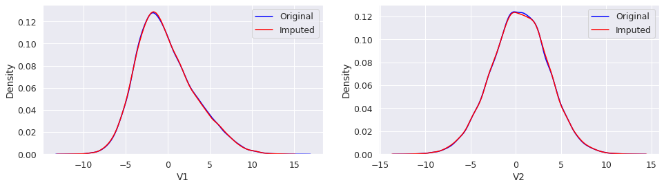

```python
# Plotting the PDFs of treated variables before and after imputation
plt.figure(figsize = (16, 4));
plt.subplot(121);
sns.kdeplot(data = df, x = 'V1', color = 'blue');
sns.kdeplot(data = X_train, x = 'V1', color = 'red');
plt.legend(['Original', 'Imputed']);
plt.subplot(122);
sns.kdeplot(data = df, x = 'V2', color = 'blue');
sns.kdeplot(data = X_train, x = 'V2', color = 'red');
plt.legend(['Original', 'Imputed']);
```

#### Observations:

As can be seen, the imputation scheme has successfully filled in all missing values, and has very well preserved the original distributions.

## ML-based Modeling

- Here, we choose Logistic Regression, Decision Tree, Bagging Classifier, Random Forest, AdaBoost Classifier, Gradient Boosting Classifier and XGBoost Classifier as our classification models.
- Among all costs defined in the problem statement, replacement cost seems the most severe. Therefore, mitigating this type of damage should be our first priority, which is only accomplished by reducing the number of FNs. Towards this end, we select maximizing *recall score* as our primary objective, which attempts to identify as many potential failures.

```python
# Auxiliary function for reporting the evaluation metrics of models
def model_eval(model, X_train, X_test, y_train, y_test, valid = True):
    '''This function calculates all relevant evaluation metrics for the classification
    model passed to it on training and validation/test sets and returns it as a dataframe.'''

    # Reconstructing the training set
    y_recon = model.predict(X_train)
    # Forecasting the validation/test set
    y_pred = model.predict(X_test)

    # Defining the dataframe of performance metrics
    if valid:
        metrics_df = pd.DataFrame(index = ['Train', 'Validation'], columns =
                                  ['Accuracy', 'Recall', 'Precision', 'F1', 'Specificity'])
    else:
        metrics_df = pd.DataFrame(index = ['Train', 'Test'], columns =
                                  ['Accuracy', 'Recall', 'Precision', 'F1', 'Specificity'])

    # Filling in the evaluation metrics
    metrics_df.iloc[0, :] = [accuracy_score(y_train, y_recon), recall_score(y_train, y_recon),
                             precision_score(y_train, y_recon), f1_score(y_train, y_recon),
                             recall_score(y_train, y_recon, pos_label = 0)]
    metrics_df.iloc[1, :] = [accuracy_score(y_test, y_pred), recall_score(y_test, y_pred),
                             precision_score(y_test, y_pred), f1_score(y_test, y_pred),
                             recall_score(y_test, y_pred, pos_label = 0)]
    return metrics_df
```

```python
# Auxiliary function for plotting the confusion matrix of classification models
def plot_cm(y_truth, y_pred):
    '''This function receives the actual data (y_truth) and the predictions of a
    classification model (y_pred), and returns the confusion matrix of the two in
    the form of a heatmap.'''

    # Calculating the confusion matrix
    cm = confusion_matrix(y_truth, y_pred)
    # Trurning the confusion matrix into a dataframe
    cm_df = pd.DataFrame(cm, index = ['Truth -- No Failure', 'Truth -- Failure'],
                         columns = ['Prediction -- No Failure', 'Prediction -- Failure'])

    # Generating the labels of the heatmap
    labels = []
    for i in range(len(cm.flatten())):
        labels.append(str(cm.flatten()[i]) + '\n(' + str(round(cm.flatten()[i]/cm.flatten().sum()*100, 2)) + '%)')
    labels = np.asarray(labels).reshape(2, 2)

    # Potting the heatmap of the confusion matrix
    sns.heatmap(cm_df, fmt = '', annot = labels, cbar = False, cmap = 'seismic',
                vmin = -1.05*len(y_truth), vmax = 1.05*len(y_truth))
    plt.xlabel('Prediction');
    plt.ylabel('Truth');
```

### Baseline Models

Here, we build untuned baseline models on the original data.

**`Logistic Regression`**

```python
# Building the baseline model
lrc0 = LogisticRegression(solver = 'liblinear', max_iter = 1000, random_state = 1)
lrc0 = lrc0.fit(X_train, y_train)
```

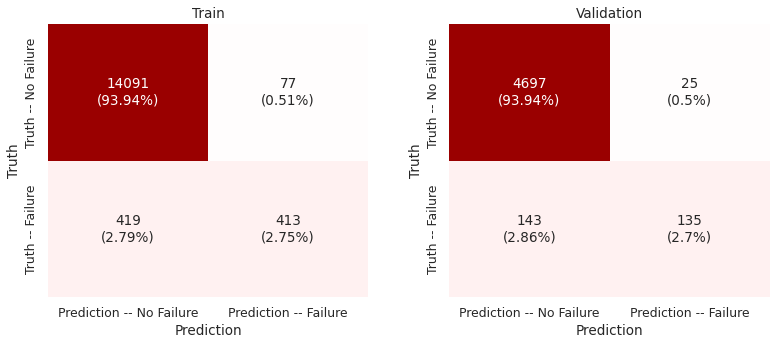

```python
# Plotting the confusion matrices of the model on training and validation sets

# Reconstructing the training set
y_recon = lrc0.predict(X_train)
# Forecasting the validation set
y_pred  = lrc0.predict(X_valid)

# Plotting the heatmaps of confusion matrices
plt.figure(figsize = (11, 5));
plt.subplot(121);
plot_cm(y_train, y_recon);
plt.title('Train');
plt.subplot(122);
plot_cm(y_valid, y_pred);
plt.title('Validation');
plt.tight_layout(w_pad = 3);
```

```python
# Reporting the performance metrics of the model on training and validation sets
lrc0_perform = model_eval(lrc0, X_train, X_valid, y_train, y_valid)
lrc0_perform
```

|  | Accuracy | Recall | Precision | F1 | Specificity |
| --- | --- | --- | --- | --- | --- |
| Train | 0.967 | 0.496 | 0.843 | 0.625 | 0.995 |
| Validation | 0.966 | 0.486 | 0.844 | 0.616 | 0.995 |

```python
# Finding the region of uncertainty for the recall score of the model

# Setting the strategy for splitting the data into 10 random folds
kfold = StratifiedKFold(n_splits = 10, shuffle = True, random_state = 1)

# Calculating the cross-validated scores
cv_results = cross_val_score(lrc0, X_train, y_train, scoring = 'recall', cv = kfold, n_jobs = -1)
cv_mean = cv_results.mean()
cv_std = cv_results.std()

# Reporting the model's average recall score and confidence interval
print('The average recall score of the model is {} and,'.format(round(cv_mean, 3)),
      'with 95% certainty, its recall score resides between {} and {}.'.format(
          round(cv_mean-2*cv_std, 3), round(cv_mean+2*cv_std, 3)))
```

```
The average recall score of the model is 0.496 and, with 95% certainty, its recall score resides between 0.389 and 0.604.
```

**`Decision Tree`**

```python
# Building the baseline model
dtr0 = DecisionTreeClassifier(random_state = 1)
dtr0 = dtr0.fit(X_train, y_train)
```

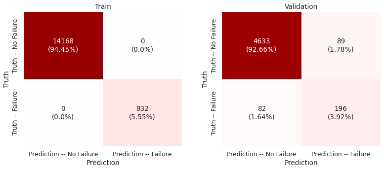

```python
# Plotting the confusion matrices of the model on training and validation sets

# Reconstructing the training set
y_recon = dtr0.predict(X_train)
# Forecasting the validation set
y_pred = dtr0.predict(X_valid)

# Plotting the heatmaps of confusion matrices
plt.figure(figsize = (11, 5));
plt.subplot(121);
plot_cm(y_train, y_recon);
plt.title('Train');
plt.subplot(122);
plot_cm(y_valid, y_pred);
plt.title('Validation');
plt.tight_layout(w_pad = 3);
```

```python
# Reporting the performance metrics of the model on training and validation sets
dtr0_perform = model_eval(dtr0, X_train, X_valid, y_train, y_valid)
dtr0_perform
```

|  | Accuracy | Recall | Precision | F1 | Specificity |
| --- | --- | --- | --- | --- | --- |
| Train | 1.000 | 1.000 | 1.000 | 1.000 | 1.000 |
| Validation | 0.966 | 0.705 | 0.688 | 0.696 | 0.981 |

```python
# Finding the region of uncertainty for the recall score of the model

# Setting the strategy for splitting the data into 10 random folds
kfold = StratifiedKFold(n_splits = 10, shuffle = True, random_state = 1)

# Calculating the cross-validated scores
cv_results = cross_val_score(dtr0, X_train, y_train, scoring = 'recall', cv = kfold, n_jobs = -1)
cv_mean = cv_results.mean()
cv_std  = cv_results.std()

# Reporting the model's average recall score and confidence interval
print('The average recall score of the model is {} and,'.format(round(cv_mean, 3)),
      'with 95% certainty, its recall score resides between {} and {}.'.format(
          round(cv_mean-2*cv_std, 3), round(cv_mean+2*cv_std, 3)))
```

```
The average recall score of the model is 0.731 and, with 95% certainty, its recall score resides between 0.631 and 0.831.
```

**`Bagging Classifier`**

```python
# Building the baseline model
bgc0 = BaggingClassifier(random_state = 1)
bgc0 = bgc0.fit(X_train, y_train)
```

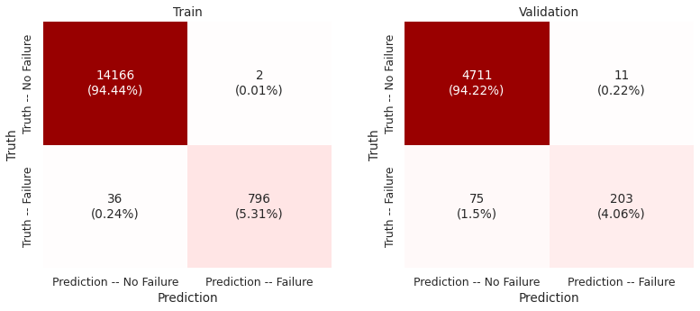

```python
# Plotting the confusion matrices of the model on training and validation sets

# Reconstructing the training set
y_recon = bgc0.predict(X_train)
# Forecasting the validation set
y_pred  = bgc0.predict(X_valid)

# Plotting the heatmaps of confusion matrices
plt.figure(figsize = (11, 5));
plt.subplot(121);
plot_cm(y_train, y_recon);
plt.title('Train');
plt.subplot(122);
plot_cm(y_valid, y_pred);
plt.title('Validation');
plt.tight_layout(w_pad = 3);
```

```python
# Reporting the performance metrics of the model on training and validation sets
bgc0_perform = model_eval(bgc0, X_train, X_valid, y_train, y_valid)
bgc0_perform
```

|  | Accuracy | Recall | Precision | F1 | Specificity |
| --- | --- | --- | --- | --- | --- |
| Train | 0.997 | 0.957 | 0.997 | 0.977 | 1.000 |
| Validation | 0.983 | 0.730 | 0.949 | 0.825 | 0.998 |

```python
# Finding the region of uncertainty for the recall score of the model

# Setting the strategy for splitting the data into 10 random folds
kfold = StratifiedKFold(n_splits = 10, shuffle = True, random_state = 1)

# Calculating the cross-validated scores
cv_results = cross_val_score(bgc0, X_train, y_train, scoring = 'recall', cv = kfold, n_jobs = -1)
cv_mean = cv_results.mean()
cv_std = cv_results.std()

# Reporting the model's average recall score and confidence interval
print('The average recall score of the model is {} and,'.format(round(cv_mean, 3)),
      'with 95% certainty, its recall score resides between {} and {}.'.format(
          round(cv_mean-2*cv_std, 3), round(cv_mean+2*cv_std, 3)))
```

```
The average recall score of the model is 0.719 and, with 95% certainty, its recall score resides between 0.614 and 0.824.
```

**`Random Forest`**

```python
# Building the baseline model
rfc0 = RandomForestClassifier(random_state = 1)
rfc0 = rfc0.fit(X_train, y_train)
```

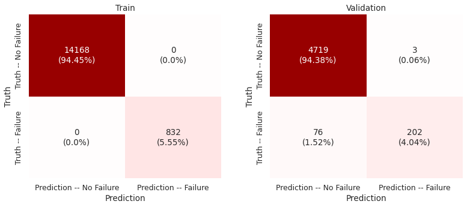

```python
# Plotting the confusion matrices of the model on training and validation sets

# Reconstructing the training set
y_recon = rfc0.predict(X_train)
# Forecasting the validation set
y_pred  = rfc0.predict(X_valid)

# Plotting the heatmaps of confusion matrices
plt.figure(figsize = (11, 5));
plt.subplot(121);
plot_cm(y_train, y_recon);
plt.title('Train');
plt.subplot(122);
plot_cm(y_valid, y_pred);
plt.title('Validation');
plt.tight_layout(w_pad = 3);
```

```python
# Reporting the performance metrics of the model on training and validation sets
rfc0_perform = model_eval(rfc0, X_train, X_valid, y_train, y_valid)
rfc0_perform
```

|  | Accuracy | Recall | Precision | F1 | Specificity |
| --- | --- | --- | --- | --- | --- |
| Train | 1.000 | 1.000 | 1.000 | 1.000 | 1.000 |
| Validation | 0.984 | 0.727 | 0.985 | 0.836 | 0.999 |

```python
# Finding the region of uncertainty for the recall score of the model

# Setting the strategy for splitting the data into 10 random folds
kfold = StratifiedKFold(n_splits = 10, shuffle = True, random_state = 1)

# Calculating the cross-validated scores
cv_results = cross_val_score(rfc0, X_train, y_train, scoring = 'recall', cv = kfold, n_jobs = -1)
cv_mean = cv_results.mean()
cv_std = cv_results.std()

# Reporting the model's average recall score and confidence interval
print('The average recall score of the model is {} and,'.format(round(cv_mean, 3)),
      'with 95% certainty, its recall score resides between {} and {}.'.format(
          round(cv_mean-2*cv_std, 3), round(cv_mean+2*cv_std, 3)))
```

```
The average recall score of the model is 0.73 and, with 95% certainty, its recall score resides between 0.615 and 0.845.
```

**`Adaptive Boosting Classifier`**

```python
# Building the baseline model
abc0 = AdaBoostClassifier(random_state = 1)
abc0 = abc0.fit(X_train, y_train)
```

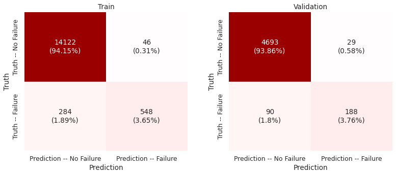

```python
# Plotting the confusion matrices of the model on training and validation sets

# Reconstructing the training set
y_recon = abc0.predict(X_train)
# Forecasting the validation set
y_pred  = abc0.predict(X_valid)

# Plotting the heatmaps of confusion matrices
plt.figure(figsize = (11, 5));
plt.subplot(121);
plot_cm(y_train, y_recon);
plt.title('Train');
plt.subplot(122);
plot_cm(y_valid, y_pred);
plt.title('Validation');
plt.tight_layout(w_pad = 3);
```

```python
# Reporting the performance metrics of the model on training and validation sets
abc0_perform = model_eval(abc0, X_train, X_valid, y_train, y_valid)
abc0_perform
```

|  | Accuracy | Recall | Precision | F1 | Specificity |
| --- | --- | --- | --- | --- | --- |
| Train | 0.978 | 0.659 | 0.923 | 0.769 | 0.997 |
| Validation | 0.976 | 0.676 | 0.866 | 0.760 | 0.994 |

```python
# Finding the region of uncertainty for the recall score of the model

# Setting the strategy for splitting the data into 10 random folds
kfold = StratifiedKFold(n_splits = 10, shuffle = True, random_state = 1)

# Calculating the cross-validated scores
cv_results = cross_val_score(abc0, X_train, y_train, scoring = 'recall', cv = kfold, n_jobs = -1)
cv_mean = cv_results.mean()
cv_std = cv_results.std()

# Reporting the model's average recall score and confidence interval
print('The average recall score of the model is {} and,'.format(round(cv_mean, 3)),
      'with 95% certainty, its recall score resides between {} and {}.'.format(
          round(cv_mean-2*cv_std, 3), round(cv_mean+2*cv_std, 3)))
```

```
The average recall score of the model is 0.62 and, with 95% certainty, its recall score resides between 0.503 and 0.737.
```

**`Gradient Boosting Classifier`**

```python
# Building the baseline model
gbc0 = GradientBoostingClassifier(random_state = 1)
gbc0 = gbc0.fit(X_train, y_train)
```

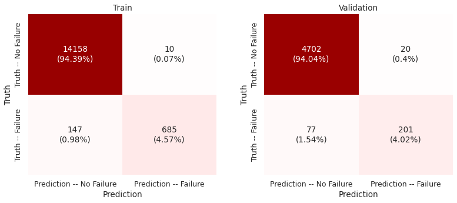

```python
# Plotting the confusion matrices of the model on training and validation sets

# Reconstructing the training set
y_recon = gbc0.predict(X_train)
# Forecasting the validation set
y_pred  = gbc0.predict(X_valid)

# Plotting the heatmaps of confusion matrices
plt.figure(figsize = (11, 5));
plt.subplot(121);
plot_cm(y_train, y_recon);
plt.title('Train');
plt.subplot(122);
plot_cm(y_valid, y_pred);
plt.title('Validation');
plt.tight_layout(w_pad = 3);
```

```python
# Reporting the performance metrics of the model on training and validation sets
gbc0_perform = model_eval(gbc0, X_train, X_valid, y_train, y_valid)
gbc0_perform
```

|  | Accuracy | Recall | Precision | F1 | Specificity |
| --- | --- | --- | --- | --- | --- |
| Train | 0.990 | 0.823 | 0.986 | 0.897 | 0.999 |
| Validation | 0.981 | 0.723 | 0.910 | 0.806 | 0.996 |

```python
# Finding the region of uncertainty for the recall score of the model

# Setting the strategy for splitting the data into 10 random folds
kfold = StratifiedKFold(n_splits = 10, shuffle = True, random_state = 1)

# Calculating the cross-validated scores
cv_results = cross_val_score(gbc0, X_train, y_train, scoring = 'recall', cv = kfold, n_jobs = -1)
cv_mean = cv_results.mean()
cv_std = cv_results.std()

# Reporting the model's average recall score and confidence interval
print('The average recall score of the model is {} and,'.format(round(cv_mean, 3)),
      'with 95% certainty, its recall score resides between {} and {}.'.format(
          round(cv_mean-2*cv_std, 3), round(cv_mean+2*cv_std, 3)))
```

```
The average recall score of the model is 0.718 and, with 95% certainty, its recall score resides between 0.609 and 0.826.
```

**`XGBoost Classifier`**

```python
# Building the baseline model
xgbc0 = XGBClassifier(eval_metric = 'logloss', random_state = 1)
xgbc0 = xgbc0.fit(X_train, y_train)
```

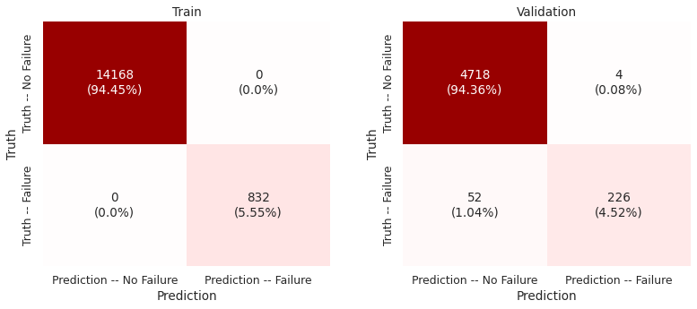

```python
# Plotting the confusion matrices of the model on training and validation sets

# Reconstructing the training set
y_recon = xgbc0.predict(X_train)
# Forecasting the validation set
y_pred  = xgbc0.predict(X_valid)

# Plotting the heatmaps of confusion matrices
plt.figure(figsize = (11, 5));
plt.subplot(121);
plot_cm(y_train, y_recon);
plt.title('Train');
plt.subplot(122);
plot_cm(y_valid, y_pred);
plt.title('Validation');
plt.tight_layout(w_pad = 3);
```

```python
# Reporting the performance metrics of the model on training and validation sets
xgbc0_perform = model_eval(xgbc0, X_train, X_valid, y_train, y_valid)
xgbc0_perform
```

|  | Accuracy | Recall | Precision | F1 | Specificity |
| --- | --- | --- | --- | --- | --- |
| Train | 1.000 | 1.000 | 1.000 | 1.000 | 1.000 |
| Validation | 0.989 | 0.813 | 0.983 | 0.890 | 0.999 |

```python
# Finding the region of uncertainty for the recall score of the model

# Setting the strategy for splitting the data into 10 random folds
kfold = StratifiedKFold(n_splits = 10, shuffle = True, random_state = 1)

# Calculating the cross-validated scores
cv_results = cross_val_score(xgbc0, X_train, y_train, scoring = 'recall', cv = kfold, n_jobs = -1)
cv_mean = cv_results.mean()
cv_std = cv_results.std()

# Reporting the model's average recall score and confidence interval
print('The average recall score of the model is {} and,'.format(round(cv_mean, 3)),
      'with 95% certainty, its recall score resides between {} and {}.'.format(
          round(cv_mean-2*cv_std, 3), round(cv_mean+2*cv_std, 3)))
```

```
The average recall score of the model is 0.799 and, with 95% certainty, its recall score resides between 0.685 and 0.914.
```

**`Comparison`**

```python
# Comparison of all baseline models on training set
baseline_compare_train = pd.concat([lrc0_perform, dtr0_perform, bgc0_perform,
                                    rfc0_perform, abc0_perform, gbc0_perform,
                                    xgbc0_perform])[::2]
baseline_compare_train.index = ['Logistic Regression (Baseline)', 'Decision Tree (Baseline)',
                                'Bagging (Baseline)', 'Random Forest (Baseline)',
                                'AdaBoost (Baseline)','Gradient Boosting (Baseline)',
                                'XGBoost (Baseline)']
baseline_compare_train.sort_values(by = 'Recall', ascending = False)
```

|  | Accuracy | Recall | Precision | F1 | Specificity |
| --- | --- | --- | --- | --- | --- |
| Decision Tree (Baseline) | 1.000 | 1.000 | 1.000 | 1.000 | 1.000 |
| Random Forest (Baseline) | 1.000 | 1.000 | 1.000 | 1.000 | 1.000 |
| XGBoost (Baseline) | 1.000 | 1.000 | 1.000 | 1.000 | 1.000 |
| Bagging (Baseline) | 0.997 | 0.957 | 0.997 | 0.977 | 1.000 |
| Gradient Boosting (Baseline) | 0.990 | 0.823 | 0.986 | 0.897 | 0.999 |
| AdaBoost (Baseline) | 0.978 | 0.659 | 0.923 | 0.769 | 0.997 |
| Logistic Regression (Baseline) | 0.967 | 0.496 | 0.843 | 0.625 | 0.995 |

```python
# Comparison of all baseline models on training set
baseline_compare_valid = pd.concat([lrc0_perform, dtr0_perform, bgc0_perform,
                                    rfc0_perform, abc0_perform, gbc0_perform,
                                    xgbc0_perform])[1::2]
baseline_compare_valid.index = ['Logistic Regression (Baseline)', 'Decision Tree (Baseline)',
                                'Bagging (Baseline)', 'Random Forest (Baseline)',
                                'AdaBoost (Baseline)', 'Gradient Boosting (Baseline)',
                                'XGBoost (Baseline)']
baseline_compare_valid.sort_values(by = 'Recall', ascending = False)
```

|  | Accuracy | Recall | Precision | F1 | Specificity |
| --- | --- | --- | --- | --- | --- |
| XGBoost (Baseline) | 0.989 | 0.813 | 0.983 | 0.890 | 0.999 |
| Bagging (Baseline) | 0.983 | 0.730 | 0.949 | 0.825 | 0.998 |
| Random Forest (Baseline) | 0.984 | 0.727 | 0.985 | 0.836 | 0.999 |
| Gradient Boosting (Baseline) | 0.981 | 0.723 | 0.910 | 0.806 | 0.996 |
| Decision Tree (Baseline) | 0.966 | 0.705 | 0.688 | 0.696 | 0.981 |
| AdaBoost (Baseline) | 0.976 | 0.676 | 0.866 | 0.760 | 0.994 |
| Logistic Regression (Baseline) | 0.966 | 0.486 | 0.844 | 0.616 | 0.995 |